# cdasws Example Jupyter Notebook

This [Jupyter notebook](https://jupyter.org) demonstrates using the cdasws Python package to access data from [cdaweb](https://cdaweb.gsfc.nasa.gov) with the data returned in the [xarray.Dataset](https://docs.xarray.dev/en/stable/generated/xarray.Dataset.html). This notebook contains the following sections:

1. Prerequisites
2. Setup
3. Get Observatory Groups
4. Get Instrument Types
5. Get Datasets
6. Get Dataset Variables
7. Get Data
8. Display Metadata
9. Plot Values
10. Binning Example
11. DOI Example
12. Additional Documentation

**Notes**:

1. This example only depends upon pure Python modules and does not require modules that depend upon non-Python code (such as spacepy and pycdf).
2. The use of the dataRepresentation keyword parameter below is only necessary if you also have spacepy installed.
3. It is possible to have the data returned in an [SpasePy data model](https://spacepy.github.io/datamodel.html). For SpasePy data model results, see this notebook (ipynb file).

## Prerequisites

Install the prerequisite software from the [Python Package Index](https://pypi.org/) if it is not already installed.

```python
#%pip install xarray
#%pip install cdflib
#%pip install cdasws
```

## Setup

Execute some preliminary code that is necessary before the code that follows.

```python
from cdasws import CdasWs
from cdasws.datarepresentation import DataRepresentation as dr
import matplotlib.pyplot as plt
cdas = CdasWs()
```

## Get Observatory Groups

The following code demonstrates how to get the available observatory groups.

```python
obs_groups = cdas.get_observatory_groups()
for index, obs_group in enumerate(obs_groups):
    print(obs_group['Name'])
    if index == 5:
        print('...')
        break
```

```
ACE
AIM
AMPTE
ARTEMIS
Alouette
Apollo
...
```

## Get Intrument Types

The following code demonstrates how to get the available instrument types.

```python
instr_types = cdas.get_instrument_types()
for index, instr_type in enumerate(instr_types):
    print(instr_type['Name'])
    if index == 5:
        print('...')
        break
```

```
Activity Indices
Electric Fields (space)
Electron Precipitation Bremsstrahlung
Energetic Particle Detector
Engineering
Ephemeris/Attitude/Ancillary
...
```

## Get Datasets

The following code demontrates how to get a list of datasets.

```python
datasets = cdas.get_datasets(observatoryGroup='ACE',
                             instrumentType='Magnetic Fields (space)')
for index, dataset in enumerate(datasets):
    print(dataset['Id'], dataset['Label'])
    if index == 5:
        print('...')
        break
```

```
AC_AT_DEF ACE Hourly RTN, GSE and J2000 GCI Attitude direction cosines - E. C. Stone (California Institute of Technology)
AC_H0_MFI H0 - ACE Magnetic Field 16-Second Level 2 Data - N. Ness (Bartol Research Institute)
AC_H1_MFI H1 - ACE Magnetic Field 4-Minute Level 2 Data - N. Ness (Bartol Research Institute)
AC_H2_MFI H2 - ACE Magnetic Field 1-Hour Level 2 Data - N. Ness (Bartol Research Institute)
AC_H3_MFI H3 - ACE Magnetic Field 1-Second Level 2 Data - N. Ness (Bartol Research Institute)
AC_K0_GIFWALK Links to ACE KP pre-generated survey and other plots - Polar-Wind-Geotail Ground System (NASA GSFC)
...
```

## Get Dataset Variables

The following code demonstrates how to get a dataset's variables.

```python
variables = cdas.get_variables('AC_H1_MFI')
for variable in variables:
    print(variable['Name'], variable['LongDescription'])
```

```
Magnitude B-field magnitude
BGSEc Magnetic Field Vector in GSE Cartesian coordinates (4 min)
BGSM Magnetic field vector in GSM coordinates (4 min)
SC_pos_GSE ACE s/c position, 3 comp. in GSE coord.
SC_pos_GSM ACE s/c position, 3 comp. in GSM coord.
```

## Get Data

The following code demonstrates how to access magnetic field measurements from the ACE AC_H1_MFI.

```python
data = cdas.get_data('AC_H1_MFI', ['Magnitude', 'BGSEc'],
                     '2009-06-01T00:00:00Z', '2009-06-01T00:10:00Z',
                     dataRepresentation = dr.XARRAY)[1]
print(data)
```

```
<xarray.Dataset> Size: 276B
Dimensions:    (Epoch: 3, cartesian: 3)
Coordinates:
  * Epoch      (Epoch) datetime64[ns] 24B 2009-06-01 ... 2009-06-01T00:08:00
  * cartesian  (cartesian) <U11 132B 'x_component' 'y_component' 'z_component'
    metavar0   (cartesian) <U6 72B 'Bx GSE' 'By GSE' 'Bz GSE'
Data variables:
    Magnitude  (Epoch) float32 12B 3.495 3.474 3.477
    BGSEc      (Epoch, cartesian) float32 36B -0.106 2.521 ... 2.309 -2.587
Attributes: (12/29)
    TITLE:                       ['ACE> Magnetometer Parameters']
    Project:                     ['ISTP>International Solar-Terrestrial Physi...
    Discipline:                  ['Space Physics>Interplanetary Studies']
    Source_name:                 ['AC>Advanced Composition Explorer']
    Data_type:                   ['H1>4-Min Level 2 Data']
    Descriptor:                  ['MAG>ACE Magnetic Field Instrument']
    ...                          ...
    Web_site:                    ['http://www.srl.caltech.edu/ACE/']
    Acknowledgement:             ['Please acknowledge the Principal', 'Please...
    Rules_of_use:                ['See the rules of use available from the AC...
    Alt_logical_source:          ['ACE_MAG_Solar-Wind-Magnetic-Field-Level2-H...
    spase_DatasetResourceID:     ['spase://NASA/NumericalData/ACE/MAG/L2/PT4M']
    CDAWEB_PARENTS:              ['ac_h1_mfi_00000000_v01', 'ac_h1_mfi_000000...
```

## Display Metadata

The following code displays metadata for the Magnitude variable.

```python
print(data.Magnitude)
```

```
<xarray.DataArray 'Magnitude' (Epoch: 3)> Size: 12B
array([3.495, 3.474, 3.477], dtype=float32)
Coordinates:
  * Epoch    (Epoch) datetime64[ns] 24B 2009-06-01 ... 2009-06-01T00:08:00
Attributes: (12/18)
    FIELDNAM:       B-field magnitude
    VALIDMIN:       [0.]
    VALIDMAX:       [500.]
    SCALEMIN:       [0.]
    SCALEMAX:       [10.]
    UNITS:          nT
    ...             ...
    LABLAXIS:       <|B|>
    DISPLAY_TYPE:   time_series
    DIM_SIZES:      [0]
    standard_name:  B-field magnitude
    units:          nT
    long_name:      <|B|>
```

## Plot Values

The following code plots the Magnitude variable's values using the label values from the metadata.

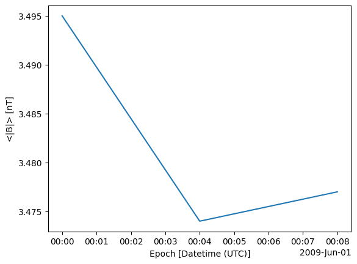

```python
data['Magnitude'].plot()
```

## Binning Example

For analysis, it is often useful to place two datasets that have different timestamps on the same time grid. The following demonstrates doing this with cdasws and the datasets AC_H0_SWE and AC_H2_SWE. For more information on binning, see [binning in cdaweb](https://cdaweb.gsfc.nasa.gov/CDAWeb_Binning_readme.html).

### Display Original Data

The following code gets and displays the original, unbinned data.

```python
    dataset0 = 'AC_H0_SWE'
    parameters = ['Np']
    start = '1998-02-04T00:00:00Z'
    stop = '1998-02-06T00:00:00Z'
    status, data0 = cdas.get_data(dataset0, parameters, start, stop,
                     dataRepresentation = dr.XARRAY)
    print(data0.Np)
    dataset1 = 'AC_H2_SWE'
    status, data1 = cdas.get_data(dataset1, parameters, start, stop,
                     dataRepresentation = dr.XARRAY)
    print(data1.Np)
```

```
<xarray.DataArray 'Np' (Epoch: 2700)> Size: 11kB
array([    nan,     nan,     nan, ..., 14.4819, 14.9483, 13.5783],
      dtype=float32)
Coordinates:
  * Epoch    (Epoch) datetime64[ns] 22kB 1998-02-04T00:00:31 ... 1998-02-05T2...
Attributes: (12/19)
    FIELDNAM:       Proton No. density
    VALIDMIN:       [0.]
    VALIDMAX:       [200.]
    SCALEMIN:       [0.]
    SCALEMAX:       [100.]
    LABLAXIS:       H_Density
    ...             ...
    DISPLAY_TYPE:   time_series
    VAR_NOTES:      Np is the proton number density in units of cm-3, as calc...
    DIM_SIZES:      [0]
    standard_name:  Proton No. density
    long_name:      H_Density
    units:          #/cc
<xarray.DataArray 'Np' (Epoch: 49)> Size: 196B
array([    nan,     nan,     nan,     nan,     nan,     nan,     nan,
           nan,     nan,     nan,     nan,     nan,     nan,     nan,
           nan,     nan,     nan,     nan,     nan,     nan,     nan,
           nan,     nan, 15.0185, 16.6551, 20.601 , 18.6789, 18.4808,
       28.3151, 22.9591, 26.7127, 28.7503, 31.1556, 29.8451, 29.6215,
       31.9601, 28.8363, 23.4173, 25.8818, 25.0207, 27.6192, 25.6742,
       25.6151, 20.008 , 14.9786, 12.0008, 13.4287, 10.4862, 10.6203],
      dtype=float32)
Coordinates:
  * Epoch    (Epoch) datetime64[ns] 392B 1998-02-04 ... 1998-02-06
Attributes: (12/19)
    FIELDNAM:       Proton No. density
    VALIDMIN:       [0.]
    VALIDMAX:       [200.]
    SCALEMIN:       [0.]
    SCALEMAX:       [100.]
    LABLAXIS:       H_Density
    ...             ...
    DISPLAY_TYPE:   time_series
    VAR_NOTES:      Np is the proton number density in units of cm-3, as calc...
    DIM_SIZES:      [0]
    standard_name:  Proton No. density
    long_name:      H_Density
    units:          #/cc
```

### Bin Data

The following code gets data after it has been binned with 60 second time intervals and any missing values created by interpolation.

```python
    binData = {
        'interval': 60.0,
        'interpolateMissingValues': True,
        'sigmaMultiplier': 4
    }
    status, data0 = cdas.get_data(dataset0, parameters, start, stop,
                     dataRepresentation = dr.XARRAY, binData=binData)
    print(data0.Np)
    status, data1 = cdas.get_data(dataset1, parameters, start, stop,
                     dataRepresentation = dr.XARRAY, binData=binData)
    print(data1.Np)
```

```
<xarray.DataArray 'Np' (Epoch_bin: 2880)> Size: 12kB
array([16.3343, 16.3343, 16.3343, ..., 14.4819, 14.9483, 13.5783],
      dtype=float32)
Coordinates:
  * Epoch_bin               (Epoch_bin) datetime64[ns] 23kB 1998-02-04T00:00:...
    NP_BIN_DELTA_MINUS_VAR  (Epoch_bin) float32 12kB nan nan nan ... nan nan nan
    NP_BIN_DELTA_PLUS_VAR   (Epoch_bin) float32 12kB nan nan nan ... nan nan nan
Attributes: (12/21)
    FIELDNAM:         Proton No. density
    VALIDMIN:         [0.]
    VALIDMAX:         [200.]
    SCALEMIN:         [0.]
    SCALEMAX:         [100.]
    LABLAXIS:         H_Density
    ...               ...
    DISPLAY_TYPE:     time_series
    VAR_NOTES:        Np is the proton number density in units of cm-3, as ca...
    DIM_SIZES:        [0]
    standard_name:    Proton No. density
    long_name:        H_Density
    units:            #/cc
<xarray.DataArray 'Np' (Epoch_bin: 2880)> Size: 12kB
array([16.6551, 16.6551, 16.6551, ..., 10.4862, 10.4862, 10.4862],
      dtype=float32)
Coordinates:
  * Epoch_bin               (Epoch_bin) datetime64[ns] 23kB 1998-02-04T00:00:...
    NP_BIN_DELTA_MINUS_VAR  (Epoch_bin) float32 12kB nan nan nan ... nan nan nan
    NP_BIN_DELTA_PLUS_VAR   (Epoch_bin) float32 12kB nan nan nan ... nan nan nan
Attributes: (12/21)
    FIELDNAM:         Proton No. density
    VALIDMIN:         [0.]
    VALIDMAX:         [200.]
    SCALEMIN:         [0.]
    SCALEMAX:         [100.]
    LABLAXIS:         H_Density
    ...               ...
    DISPLAY_TYPE:     time_series
    VAR_NOTES:        Np is the proton number density in units of cm-3, as ca...
    DIM_SIZES:        [0]
    standard_name:    Proton No. density
    long_name:        H_Density
    units:            #/cc
```

### Compare Data

The following code compares the binned data from the two datasets by plotting the values.

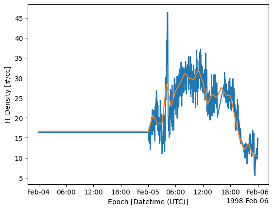

```python
data0['Np'].plot()
data1['Np'].plot()
```

## DOI Example

The following code gets data from a dataset using the dataset's [digital object identifier](https://en.wikipedia.org/wiki/Digital_object_identifier) and displays the dataset's values.

```python
doi = '10.21978/P8PG8V'
print(cdas.get_citation(doi))
print()
status, data = cdas.get_data(doi, ['BT'],
                             '1987-09-24T00:00:00Z', '1987-09-25T00:00:00Z',
                            dataRepresentation = dr.XARRAY)
print(data.BT)
```

```
Russell, C. T. (1987). <i>ISEE 2 magnetometer 4-sec data</i> [Data set]. University of California, Los Angeles and NASA’s Space Physics Data Facility. https://doi.org/10.21978/P8PG8V

<xarray.DataArray 'BT' (Epoch: 15024)> Size: 60kB
array([89.8591, 89.7978, 89.7269, ..., 18.5909, 18.6276, 18.5359],
      dtype=float32)
Coordinates:
  * Epoch    (Epoch) datetime64[ns] 120kB 1987-09-24T00:30:01.567000 ... 1987...
Attributes: (12/16)
    FIELDNAM:       BTOT
    CATDESC:        Total Magnetic Field: 12-sec avg at 4-sec intervals
    DEPEND_0:       Epoch
    DISPLAY_TYPE:   time_series
    FILLVAL:        [-1.e+31]
    FORMAT:         F9.2
    ...             ...
    VAR_TYPE:       data
    SCALETYP:       linear
    DIM_SIZES:      [0]
    standard_name:  BTOT
    long_name:      BTOT (SC)
    units:          nT
```

## Additional Documentation

View the [cdasws API](https://cdaweb.gsfc.nasa.gov/WebServices/REST/py/cdasws/) for additional functions. Additional [notebook examples](https://cdaweb.gsfc.nasa.gov/WebServices/REST/#Jupyter_Notebook_Examples) are also available.